# 607 HW2 - R and SQL

Jeff Shamp

2/6/2020

# SQL Database Access in R - Movie Ratings 2020

This assignment seems to ask for a database setup for individually collected movie ratings per student. Then some form of analysis of those results with a special emphasis on handling missing values. In general, I’ll pull information from SQL when needed and do most data manipulation in R as it is easier and faster and does not require a password each time.

## Password Masking

I could not find an all-in-one password mask for both `.Rmd` and `HTML` versions of this work so I had to imploy two masking techniques to effectively hide my database password.

### Mask For `.Rmd` File

The `keyring` package is a very simplest setup. The downside to this approach is that you need to enter the password for each session. Also `keyring` does not like the knitting process, so it throws a couple of warning messages in the `HTML` file and cannot be used while rendering `HTML`. In the `.Rmd` file on github you will see a variable `password` to store the password for the database.

### Mask For `.HTML` File

Since `keyring` does not support `HTML`, I set a parameter in this markdown file to store the database password. When knitting, the password is not displayed to the `HTML` file. Parameters can be found the beginning of R markdown files and look like this:

```markdown
---
title: "607 HW2 - R and SQL"
author: "Jeff Shamp"
date: "2/6/2020"
output:
  html_document: default
params:
  pwd:  "<totaly not my password>"
---
```

The file published to Rpubs contains the parameter `pwd` and can be used in the R code for accessing the database by `params$pwd`. When knitting this file is changed to look like the following.

```markdown
run.sql<- function(query, db_name){
  conn <-
    dbConnect(
      RMySQL::MySQL(),
      username = user_id,
      password = params$pwd,
      host = '34.68.193.229',
      dbname = db_name,
      UID = user_id,
      PWD = password
    )
```

I hope someone else came up with a more effcient way to do this!

## Extraction

I’m using the follow libraries: **DBI, RMySQL, keyring, dplyr, tidyr, and ggplot2**

Using the `keyring` package to secure database password.

```r
key_set(service = "gcp-db",
        username = "root")
```

```
## WARNING: your platform is not supported. Input is not masked!
```

```
## Password:
```

```r
user_id<- key_list("gcp-db")[1,2]
password<- key_get("gcp-db", "root")
```

This is a function to return an R dataframe from a GCP SQL database. This makes data access more reusable.

```r
run.sql<- function(query, db_name){
  conn <-
    dbConnect(
      RMySQL::MySQL(),
      username = user_id,
      password = params$pwd,
      host = '34.68.193.229',
      dbname = db_name,
      UID = user_id,
      PWD = password
    )
  result <- dbSendQuery(conn, query)
  data <- dbFetch(result)
  dbDisconnect(conn)
  return(data)
}
```

I also loaded the tb database onto my GCP so we can also access that data directly from RStudio. This also shows the ease of the `run.sql` function. All I need is a query and database name to fetch a new R dataframe.

```r
query<- paste("
              select country,
              min(year) as min_year,
              max(year) as max_year
              from tb
              group by country

               ")
df_tb<-run.sql(query, "tb")
head(df_tb)
```

```
##       country min_year max_year
## 1 Afghanistan     1995     2013
## 2     Algeria     1995     2013
## 3      Angola     1995     2013
## 4   Argentina     1995     2013
## 5  Azerbaijan     1995     2013
## 6  Bangladesh     1995     2013
```

I built the `2020_movie_ratings` db to have two tables. One for general rating and one for the movie’s oscar worthiness according to the reviewer. Below is a query to access, join and average the general rating and oscar worthiness into on data frame.

```r
query<- paste("
              SELECT r.movie,
              AVG(r.rating) AS avg_rating,
              AVG(o.rating) AS avg_oscar
              FROM ratings AS r
              JOIN oscars AS o
              ON r.movie = o.movie
              GROUP BY r.movie
              ORDER BY avg_rating
              ")
df<-run.sql(query, "2020_movie_ratings")
df
```

```
##                        movie avg_rating avg_oscar
## 1               little_women     2.4286    2.5714
## 2               the_irishman     2.6667    3.6667
## 3                   hustlers     3.3333    2.8333
## 4             marriage_story     3.5000    3.6250
## 5               the_farewell     4.1667    4.1667
## 6         nineteen_seventeen     4.2500    4.5000
## 7                      Joker     4.4000    3.8000
## 8 once_upon_a_time_hollywood     4.5000    4.0000
```

These are the averaged numbers for each table. I’ll pull down each table and examine the missing values in R. The sample here is really small, so this is a trivial example, but with a large data set, filling values is very useful especially if you are going to predict values in the future.

```r
query<- paste("
              SELECT * FROM ratings
              ")
rating_df<-run.sql(query, "2020_movie_ratings")
query<- paste("
              SELECT * FROM oscars
              ")
oscar_df<-run.sql(query, "2020_movie_ratings")
```

## Transformation

Let’s first explore the ratings table and the percent missing.

```r
sum(is.na(rating_df$rating))/dim(rating_df)[1]
```

```
## [1] 0.328125
```

One third are missing. Why don’t grad students watch more movies? I think it would be a huge stretch to fill these values, but maybe we can drop a movie if it has not been viewed by many people.

What was the most unwatched movie?

```r
unwatched<-subset(rating_df %>% group_by(movie) %>% count(rating), is.na(rating)==T,-rating)
unwatched[order(unwatched$n,decreasing = T),]
```

```
## # A tibble: 7 x 2
## # Groups:   movie [7]
##   movie                          n
##   <chr>                      <int>
## 1 the_irishman                   5
## 2 nineteen_seventeen             4
## 3 once_upon_a_time_hollywood     4
## 4 Joker                          3
## 5 hustlers                       2
## 6 the_farewell                   2
## 7 little_women                   1
```

Wow. I did not expect that. Only three people have watched The Irishman (only 8 surveys filled out). I’ll drop it and find a way to fill the other values.

```r
rating_df<-subset(rating_df, movie != 'the_irishman')
oscar_df<- subset(oscar_df, movie != 'the_irishman')
```

```r
rating_count<-rating_df %>% group_by(movie, rating) %>% tally()
rating_count
```

```
## # A tibble: 28 x 3
## # Groups:   movie [7]
##    movie        rating     n
##    <chr>         <int> <int>
##  1 hustlers          1     1
##  2 hustlers          2     1
##  3 hustlers          3     1
##  4 hustlers          4     1
##  5 hustlers          5     2
##  6 hustlers         NA     2
##  7 Joker             4     3
##  8 Joker             5     2
##  9 Joker            NA     3
## 10 little_women      1     4
## # … with 18 more rows
```

Let’s look at the distribution of values to see if a simple tactic like mean imputation would be a clearly horrible idea.

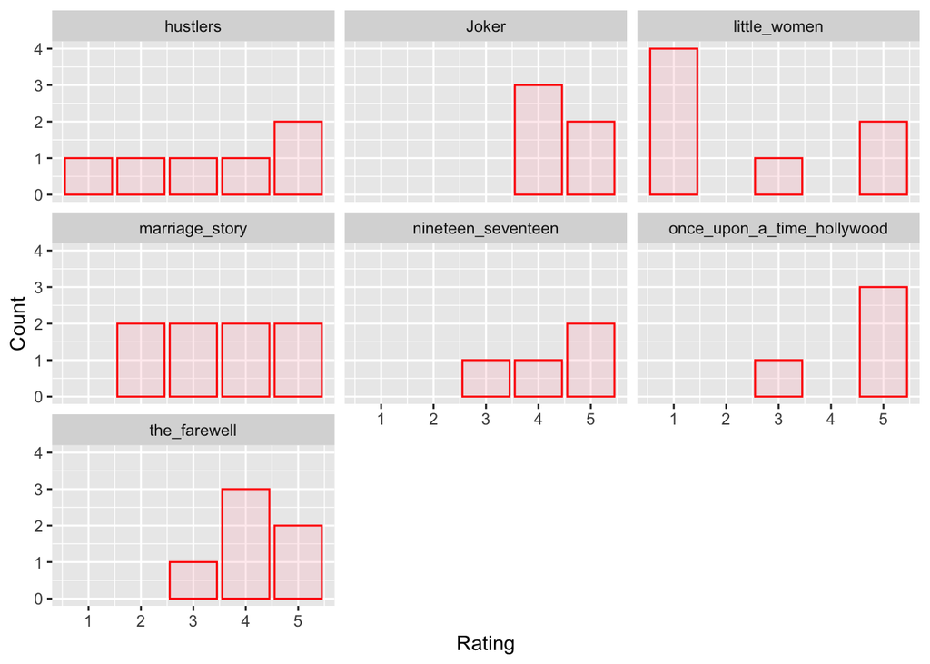

```r
ggplot(rating_count, aes(x=rating))  +
  geom_col(aes(x=rating, y=n), na.rm=T,position='dodge',alpha=.3,fill='pink',color='red') +
  facet_wrap(~movie) +
  labs(x="Rating", y="Count")
```

```r
movies<-c('Joker','marriage_story','once_upon_a_time_hollywood', 'nineteen_seventeen','hustlers','the_farewell','little_women')
for (i in 1:7){
  col_mean<-mean(subset(rating_df, movie==movies[i])$rating, na.rm = T)
  col_mean_oscar<-mean(subset(oscar_df, movie==movies[i])$rating, na.rm = T)

  if (is.na(col_mean)==F){
    rating_df[rating_df$movie==movies[i] &
     is.na(rating_df$rating)==T,]$rating<- replace_na(rating_df[rating_df$movie==movies[i] &
                                            is.na(rating_df$rating)==T,]$rating,col_mean)
    oscar_df[oscar_df$movie==movies[i] &
     is.na(oscar_df$rating)==T,]$rating<- replace_na(oscar_df[oscar_df$movie==movies[i] &
                                            is.na(oscar_df$rating)==T,]$rating,col_mean_oscar)
  }
}
```

Now we have a dataframe with values filled by each movies average rating.

As a check that the values have been filled.

```r
sum(is.na(rating_df))
```

```
## [1] 0
```

```r
sum(is.na(oscar_df))
```

```
## [1] 0
```

Great.

```r
rating_df <-rating_df %>%
  group_by(movie) %>%
    summarise(rating = mean(rating)) %>%
      rename(
        avg_rating = rating
      )
oscar_df <-oscar_df %>%
  group_by(movie) %>%
    summarise(rating = mean(rating)) %>%
      rename(
        avg_rating = rating
      )
```

Now we have both dataframes aggregated and null values are filled with their movie group average. I’ll merge them back together.

## Analysis

```r
movie_df<- merge(rating_df, oscar_df, by="movie", suffixes = c("_general", "_oscar"))
row.names(movie_df)<-1:nrow(movie_df)
movie_df
```

```
##                        movie avg_rating_general avg_rating_oscar
## 1                   hustlers           3.333333         2.833333
## 2                      Joker           4.400000         3.800000
## 3               little_women           2.428571         2.571429
## 4             marriage_story           3.500000         3.625000
## 5         nineteen_seventeen           4.250000         4.500000
## 6 once_upon_a_time_hollywood           4.500000         4.000000
## 7               the_farewell           4.166667         4.166667
```

Again, this is a trivial example as the dataset has only eight observations so filling with the mean value has not meaningfully changed the average ratings from when NAs were present.

Nonetheless, let’s look at results for some kind of insight.

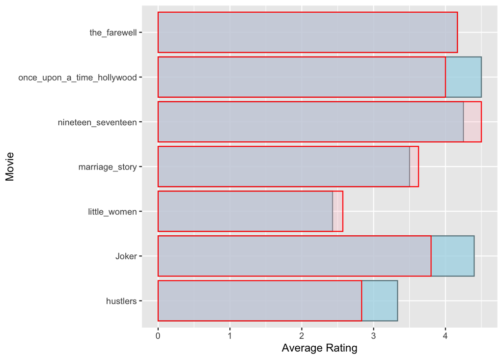

```r
ggplot(data = movie_df, aes(x=movie)) +
  geom_col(aes(x=movie,y=avg_rating_general),position='dodge',alpha=.8,fill='lightblue',color='lightblue4')+
  geom_col(aes(x=movie,y=avg_rating_oscar), position='dodge',alpha=.3,fill='pink',color='red') +
  coord_flip()+
  labs(x = "Movie",y = "Average Rating",color = "Legend")
```

Here we see the blue represent general rating and red represent oscar worthiness. Hustlers, Joker, and Once Upon A Time in Hollywood seemed to be well liked, but not considered as oscar worthy. This is the opposite for 1917, Marriage Story, and Little Women who seem to be consider more of oscar material even if the review did not like them as much. The Farewell was the only movie that was tied in general and oscar worthiness, it’s a shame The Farewell was not nominated for an oscar.